# actuarial Data Science

fazal hyder

2024-08-11

# Goal of this project is to predict the target customers who would be intrested in getting a car insurance and would could be the premium of their insurance on the basis of their driving records and personal data.

```r
library(dplyr)
library(pROC)
library(GGally)
library(corrplot)
library(caret)
library(psych)
library(rpart)
library(randomForest)
library(nnet)
library(e1071)
library(naivebayes)
library(readxl)
library(tidyverse)
data <- read_csv("Downloads/Car_Insurance_Claim.csv")
# Load necessary library
library(dplyr)

# Remove the ID column using dplyr's select function
data <- data %>% dplyr::select(-ID)

# Verify the column has been removed
head(data)
```

```
## # A tibble: 6 × 18
##   AGE   GENDER RACE     DRIVING_EXPERIENCE EDUCATION   INCOME       CREDIT_SCORE
##   <chr> <chr>  <chr>    <chr>              <chr>       <chr>               <dbl>
## 1 65+   female majority 0-9y               high school upper class         0.629
## 2 16-25 male   majority 0-9y               none        poverty             0.358
## 3 16-25 female majority 0-9y               high school working cla…        0.493
## 4 16-25 male   majority 0-9y               university  working cla…        0.206
## 5 26-39 male   majority 10-19y             none        working cla…        0.388
## 6 40-64 female majority 20-29y             high school upper class         0.619
## # ℹ 11 more variables: VEHICLE_OWNERSHIP <dbl>, VEHICLE_YEAR <chr>,
## #   MARRIED <dbl>, CHILDREN <dbl>, POSTAL_CODE <dbl>, ANNUAL_MILEAGE <dbl>,
## #   VEHICLE_TYPE <chr>, SPEEDING_VIOLATIONS <dbl>, DUIS <dbl>,
## #   PAST_ACCIDENTS <dbl>, OUTCOME <dbl>
```

```r
summary(data)
```

```
##      AGE               GENDER              RACE           DRIVING_EXPERIENCE
##  Length:10000       Length:10000       Length:10000       Length:10000
##  Class :character   Class :character   Class :character   Class :character
##  Mode  :character   Mode  :character   Mode  :character   Mode  :character
##
##
##
##
##   EDUCATION            INCOME           CREDIT_SCORE    VEHICLE_OWNERSHIP
##  Length:10000       Length:10000       Min.   :0.0534   Min.   :0.000
##  Class :character   Class :character   1st Qu.:0.4172   1st Qu.:0.000
##  Mode  :character   Mode  :character   Median :0.5250   Median :1.000
##                                        Mean   :0.5158   Mean   :0.697
##                                        3rd Qu.:0.6183   3rd Qu.:1.000
##                                        Max.   :0.9608   Max.   :1.000
##                                        NA's   :982
##  VEHICLE_YEAR          MARRIED          CHILDREN       POSTAL_CODE
##  Length:10000       Min.   :0.0000   Min.   :0.0000   Min.   :10238
##  Class :character   1st Qu.:0.0000   1st Qu.:0.0000   1st Qu.:10238
##  Mode  :character   Median :0.0000   Median :1.0000   Median :10238
##                     Mean   :0.4982   Mean   :0.6888   Mean   :19865
##                     3rd Qu.:1.0000   3rd Qu.:1.0000   3rd Qu.:32765
##                     Max.   :1.0000   Max.   :1.0000   Max.   :92101
##
##  ANNUAL_MILEAGE  VEHICLE_TYPE       SPEEDING_VIOLATIONS      DUIS
##  Min.   : 2000   Length:10000       Min.   : 0.000      Min.   :0.0000
##  1st Qu.:10000   Class :character   1st Qu.: 0.000      1st Qu.:0.0000
##  Median :12000   Mode  :character   Median : 0.000      Median :0.0000
##  Mean   :11697                      Mean   : 1.483      Mean   :0.2392
##  3rd Qu.:14000                      3rd Qu.: 2.000      3rd Qu.:0.0000
##  Max.   :22000                      Max.   :22.000      Max.   :6.0000
##  NA's   :957
##  PAST_ACCIDENTS      OUTCOME
##  Min.   : 0.000   Min.   :0.0000
##  1st Qu.: 0.000   1st Qu.:0.0000
##  Median : 0.000   Median :0.0000
##  Mean   : 1.056   Mean   :0.3133
##  3rd Qu.: 2.000   3rd Qu.:1.0000
##  Max.   :15.000   Max.   :1.0000
##
```

## Step - 1(DATA CLEANING & PREPROCESSING)

### Let’s check for the null values , missing values, range and other descriptive Statistics of the Data

```r
data_info <- str(data)
```

```
## tibble [10,000 × 18] (S3: tbl_df/tbl/data.frame)
##  $ AGE                : chr [1:10000] "65+" "16-25" "16-25" "16-25" ...
##  $ GENDER             : chr [1:10000] "female" "male" "female" "male" ...
##  $ RACE               : chr [1:10000] "majority" "majority" "majority" "majority" ...
##  $ DRIVING_EXPERIENCE : chr [1:10000] "0-9y" "0-9y" "0-9y" "0-9y" ...
##  $ EDUCATION          : chr [1:10000] "high school" "none" "high school" "university" ...
##  $ INCOME             : chr [1:10000] "upper class" "poverty" "working class" "working class" ...
##  $ CREDIT_SCORE       : num [1:10000] 0.629 0.358 0.493 0.206 0.388 ...
##  $ VEHICLE_OWNERSHIP  : num [1:10000] 1 0 1 1 1 1 0 0 0 1 ...
##  $ VEHICLE_YEAR       : chr [1:10000] "after 2015" "before 2015" "before 2015" "before 2015" ...
##  $ MARRIED            : num [1:10000] 0 0 0 0 0 0 1 0 1 0 ...
##  $ CHILDREN           : num [1:10000] 1 0 0 1 0 1 1 1 0 1 ...
##  $ POSTAL_CODE        : num [1:10000] 10238 10238 10238 32765 32765 ...
##  $ ANNUAL_MILEAGE     : num [1:10000] 12000 16000 11000 11000 12000 13000 13000 14000 13000 11000 ...
##  $ VEHICLE_TYPE       : chr [1:10000] "sedan" "sedan" "sedan" "sedan" ...
##  $ SPEEDING_VIOLATIONS: num [1:10000] 0 0 0 0 2 3 7 0 0 0 ...
##  $ DUIS               : num [1:10000] 0 0 0 0 0 0 0 0 0 0 ...
##  $ PAST_ACCIDENTS     : num [1:10000] 0 0 0 0 1 3 3 0 0 0 ...
##  $ OUTCOME            : num [1:10000] 0 1 0 0 1 0 0 1 0 1 ...
```

```r
# Count missing values for each column
missing_values <- sapply(data, function(x) sum(is.na(x)))
print("Missing values in each column:")
```

```
## [1] "Missing values in each column:"
```

```r
print(missing_values)
```

```
##                 AGE              GENDER                RACE  DRIVING_EXPERIENCE
##                   0                   0                   0                   0
##           EDUCATION              INCOME        CREDIT_SCORE   VEHICLE_OWNERSHIP
##                   0                   0                 982                   0
##        VEHICLE_YEAR             MARRIED            CHILDREN         POSTAL_CODE
##                   0                   0                   0                   0
##      ANNUAL_MILEAGE        VEHICLE_TYPE SPEEDING_VIOLATIONS                DUIS
##                 957                   0                   0                   0
##      PAST_ACCIDENTS             OUTCOME
##                   0                   0
```

```r
# Descriptive statistics for each column
descriptive_stats <- summary(data)
```

###. As we can see there are na values in variable ‘ANNUAL_MILEAGE’ and ‘CREDIT_SCORE’ .I will clean the Variable ‘ANNUAL_MILEAGE’ and try to reserach more about the variable ‘CREDIT_SCORE’

```r
data_clean <- data %>% filter(!is.na(ANNUAL_MILEAGE))
# Check for NA values in the ANNUAL_MILEAGE column of the data_clean dataset
na_count_annual_mileage_clean <- sum(is.na(data_clean$ANNUAL_MILEAGE))
print(paste("Number of NA values in ANNUAL_MILEAGE (data_clean):", na_count_annual_mileage_clean))
```

```
## [1] "Number of NA values in ANNUAL_MILEAGE (data_clean): 0"
```

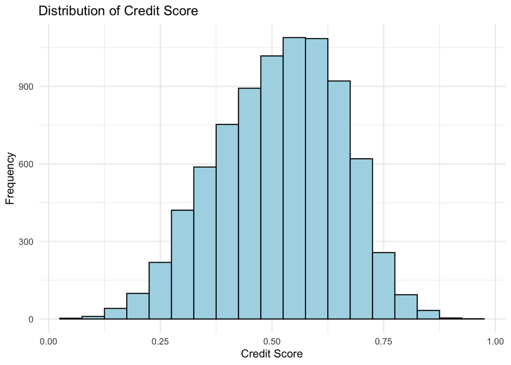

```r
# Load the necessary library
library(ggplot2)

# Histogram of CREDIT_SCORE
ggplot(data_clean, aes(x = CREDIT_SCORE)) +
  geom_histogram(binwidth = 0.05, fill = "lightblue", color = "black") +
  labs(title = "Distribution of Credit Score", x = "Credit Score", y = "Frequency") +
  theme_minimal()
```

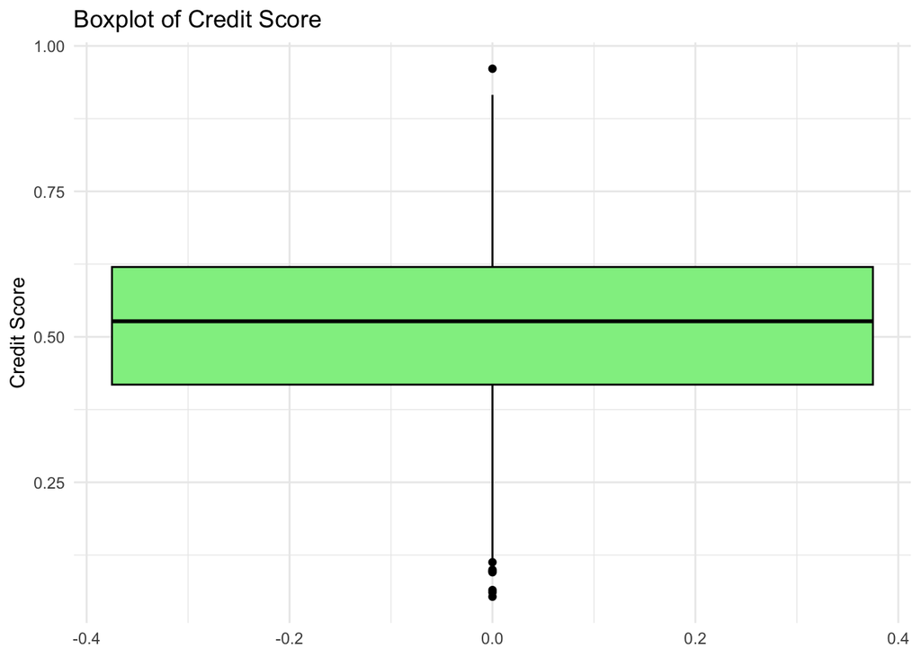

```r
# Boxplot of CREDIT_SCORE
ggplot(data_clean, aes(y = CREDIT_SCORE)) +
  geom_boxplot(fill = "lightgreen", color = "black") +
  labs(title = "Boxplot of Credit Score", y = "Credit Score") +
  theme_minimal()
```

### Assuming credit score is one of the significant variables in predicting premiums and potential customer I will not get rid of it instead assign a user defined constant ‘0’ Which means no credit history.

```r
# Replace NA values in CREDIT_SCORE with 0
data_clean$CREDIT_SCORE[is.na(data_clean$CREDIT_SCORE)] <- 0

# Verify the change by checking for remaining NA values
na_count_credit_score_clean <- sum(is.na(data_clean$CREDIT_SCORE))
print(paste("Number of NA values in CREDIT_SCORE (data_clean) after replacement:", na_count_credit_score_clean))
```

```
## [1] "Number of NA values in CREDIT_SCORE (data_clean) after replacement: 0"
```

```r
# Display the first few rows of the updated dataset
head(data_clean)
```

```
## # A tibble: 6 × 18
##   AGE   GENDER RACE     DRIVING_EXPERIENCE EDUCATION   INCOME       CREDIT_SCORE
##   <chr> <chr>  <chr>    <chr>              <chr>       <chr>               <dbl>
## 1 65+   female majority 0-9y               high school upper class         0.629
## 2 16-25 male   majority 0-9y               none        poverty             0.358
## 3 16-25 female majority 0-9y               high school working cla…        0.493
## 4 16-25 male   majority 0-9y               university  working cla…        0.206
## 5 26-39 male   majority 10-19y             none        working cla…        0.388
## 6 40-64 female majority 20-29y             high school upper class         0.619
## # ℹ 11 more variables: VEHICLE_OWNERSHIP <dbl>, VEHICLE_YEAR <chr>,
## #   MARRIED <dbl>, CHILDREN <dbl>, POSTAL_CODE <dbl>, ANNUAL_MILEAGE <dbl>,
## #   VEHICLE_TYPE <chr>, SPEEDING_VIOLATIONS <dbl>, DUIS <dbl>,
## #   PAST_ACCIDENTS <dbl>, OUTCOME <dbl>
```

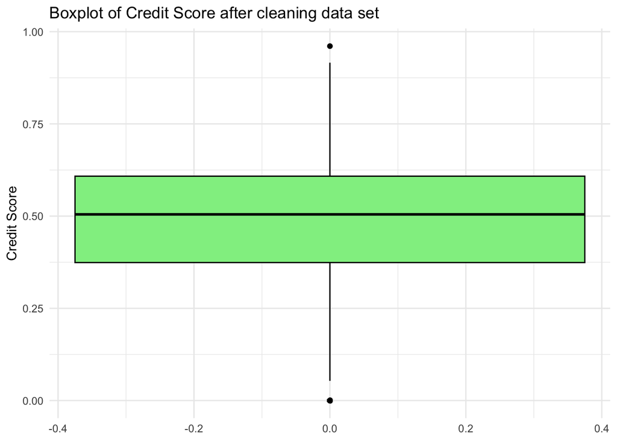

```r
ggplot(data_clean, aes(y = CREDIT_SCORE)) +
  geom_boxplot(fill = "lightgreen", color = "black") +
  labs(title = "Boxplot of Credit Score after cleaning data set", y = "Credit Score") +
  theme_minimal()
```

## Step - 2 (EXPLORATORY DATA ANALYSIS & VISUALIZATION )

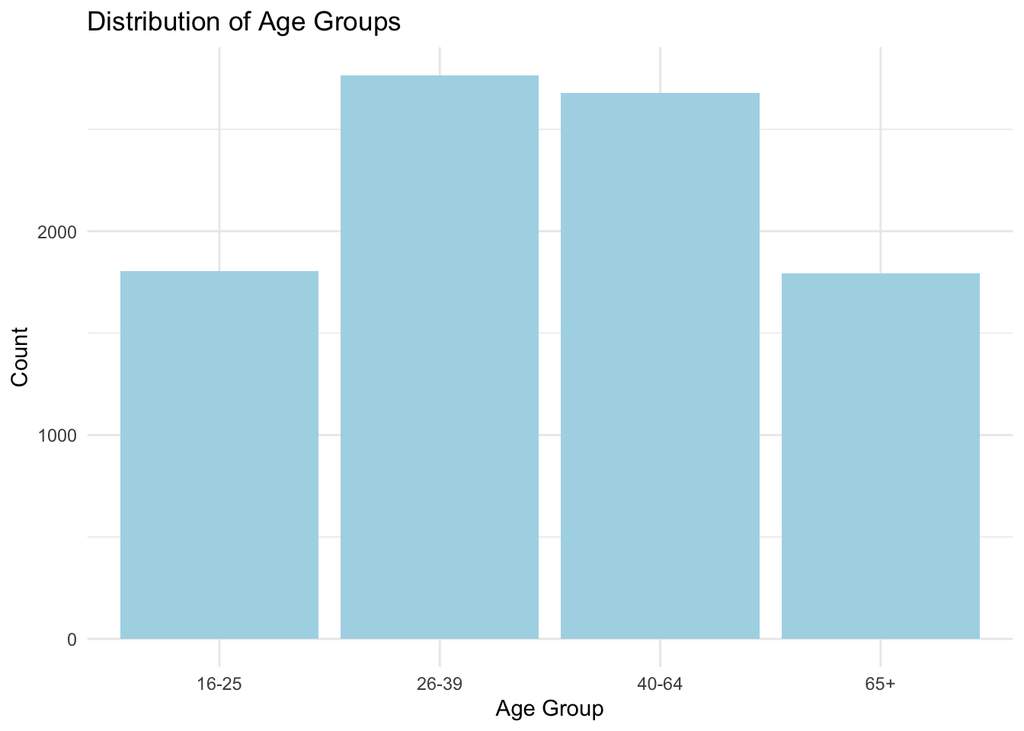

```r
# Load necessary library
library(ggplot2)

# Define colors
color_light_green <- "lightgreen"
color_light_blue <- "lightblue"

# Bar chart for AGE
ggplot(data_clean, aes(x = factor(AGE))) +
  geom_bar(fill = color_light_blue) +
  labs(title = "Distribution of Age Groups", x = "Age Group", y = "Count") +
  theme_minimal()
```

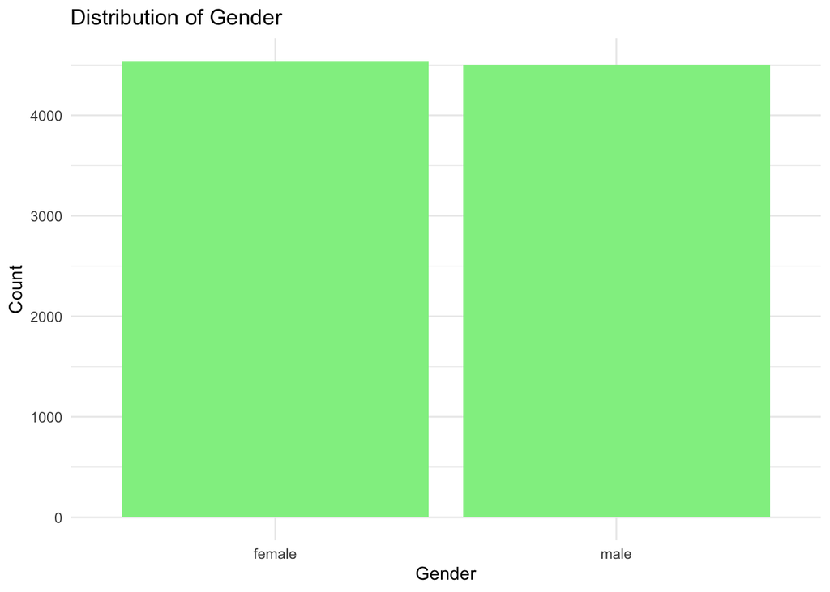

```r
# Bar chart for GENDER
ggplot(data_clean, aes(x = factor(GENDER))) +
  geom_bar(fill = color_light_green) +
  labs(title = "Distribution of Gender", x = "Gender", y = "Count") +
  theme_minimal()
```

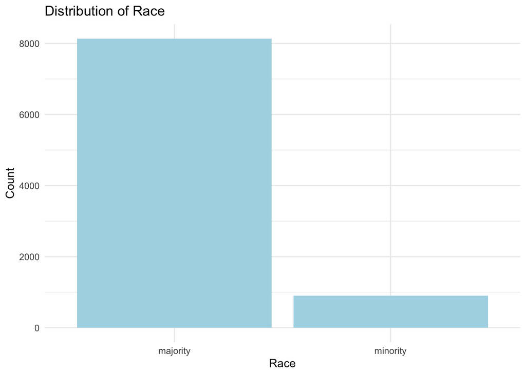

```r
# Bar chart for RACE
ggplot(data_clean, aes(x = factor(RACE))) +
  geom_bar(fill = color_light_blue) +
  labs(title = "Distribution of Race", x = "Race", y = "Count") +
  theme_minimal()
```

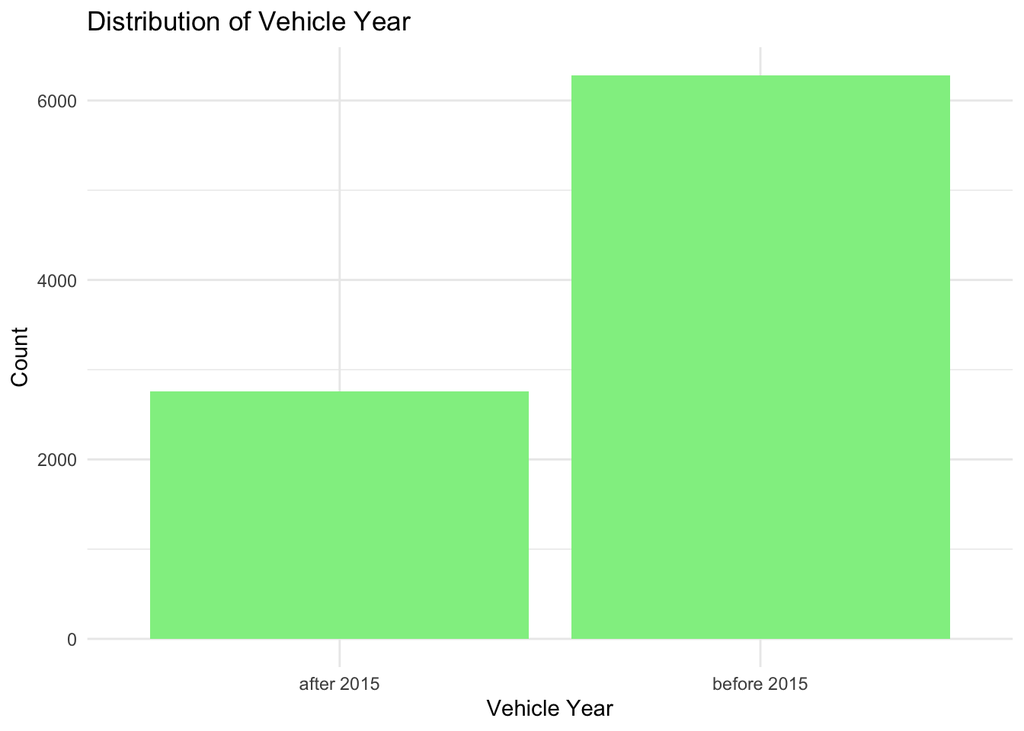

```r
# Bar chart for VEHICLE_YEAR
ggplot(data_clean, aes(x = factor(VEHICLE_YEAR))) +
  geom_bar(fill = color_light_green) +
  labs(title = "Distribution of Vehicle Year", x = "Vehicle Year", y = "Count") +
  theme_minimal()
```

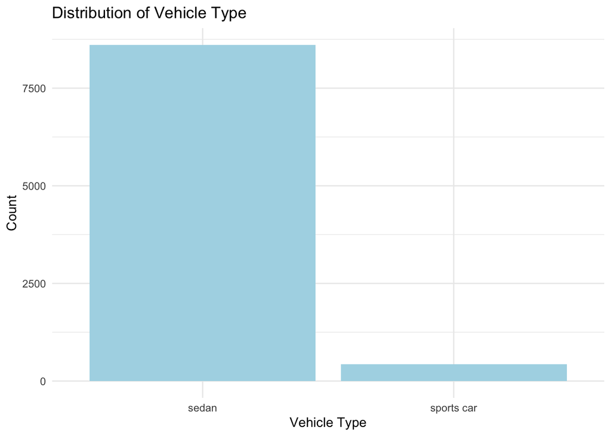

```r
# Bar chart for VEHICLE_TYPE
ggplot(data_clean, aes(x = factor(VEHICLE_TYPE))) +
  geom_bar(fill = color_light_blue) +
  labs(title = "Distribution of Vehicle Type", x = "Vehicle Type", y = "Count") +
  theme_minimal()
```

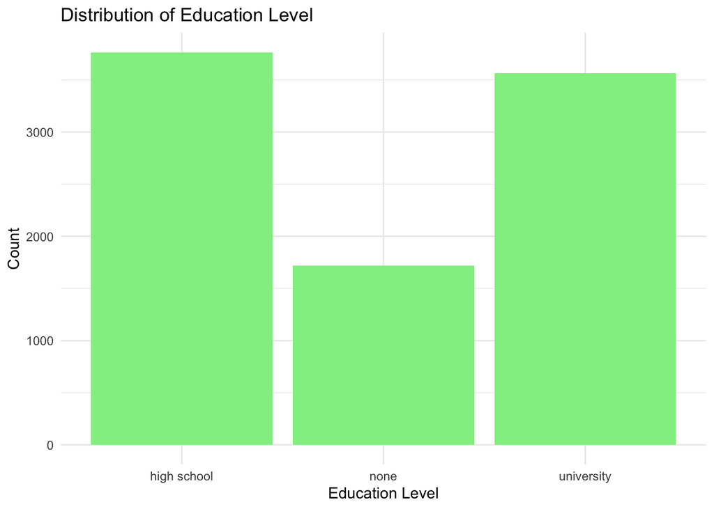

```r
# Bar chart for EDUCATION
ggplot(data_clean, aes(x = factor(EDUCATION))) +
  geom_bar(fill = color_light_green) +
  labs(title = "Distribution of Education Level", x = "Education Level", y = "Count") +
  theme_minimal()
```

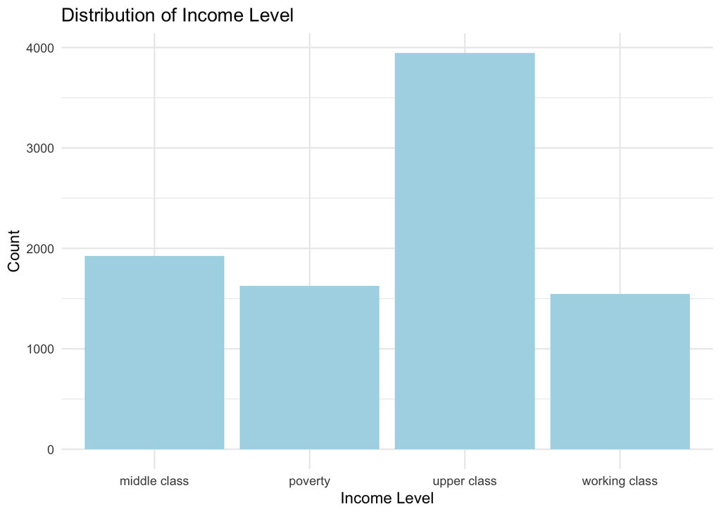

```r
# Bar chart for INCOME
ggplot(data_clean, aes(x = factor(INCOME))) +
  geom_bar(fill = color_light_blue) +
  labs(title = "Distribution of Income Level", x = "Income Level", y = "Count") +
  theme_minimal()
```

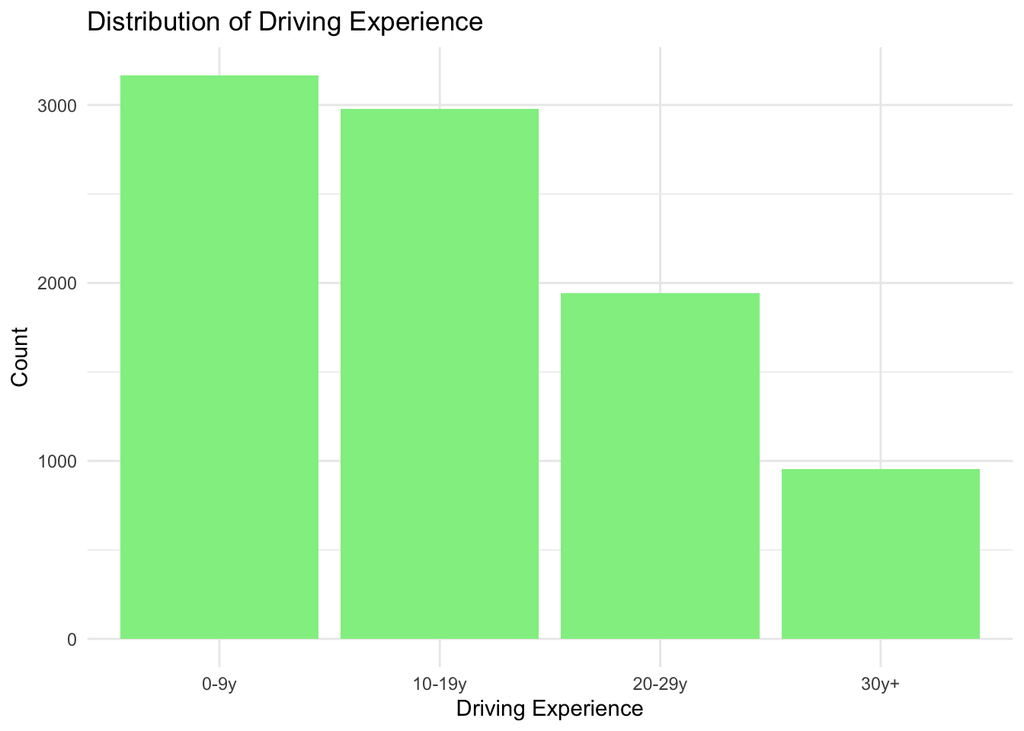

```r
# Bar chart for DRIVING_EXPERIENCE
ggplot(data_clean, aes(x = factor(DRIVING_EXPERIENCE))) +
  geom_bar(fill = color_light_green) +
  labs(title = "Distribution of Driving Experience", x = "Driving Experience", y = "Count") +
  theme_minimal()
```

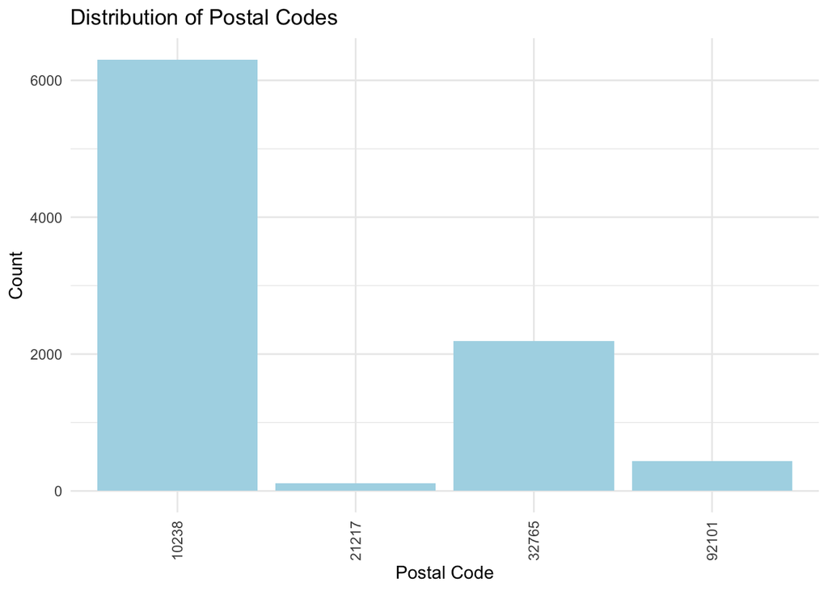

```r
# Load necessary library
library(ggplot2)

# Define colors
color_light_green <- "lightgreen"
color_light_blue <- "lightblue"

# Bar chart for POSTAL_CODE
ggplot(data_clean, aes(x = factor(POSTAL_CODE))) +
  geom_bar(fill = color_light_blue) +
  labs(title = "Distribution of Postal Codes", x = "Postal Code", y = "Count") +
  theme_minimal() +
  theme(axis.text.x = element_text(angle = 90, vjust = 0.5, hjust=1))
```

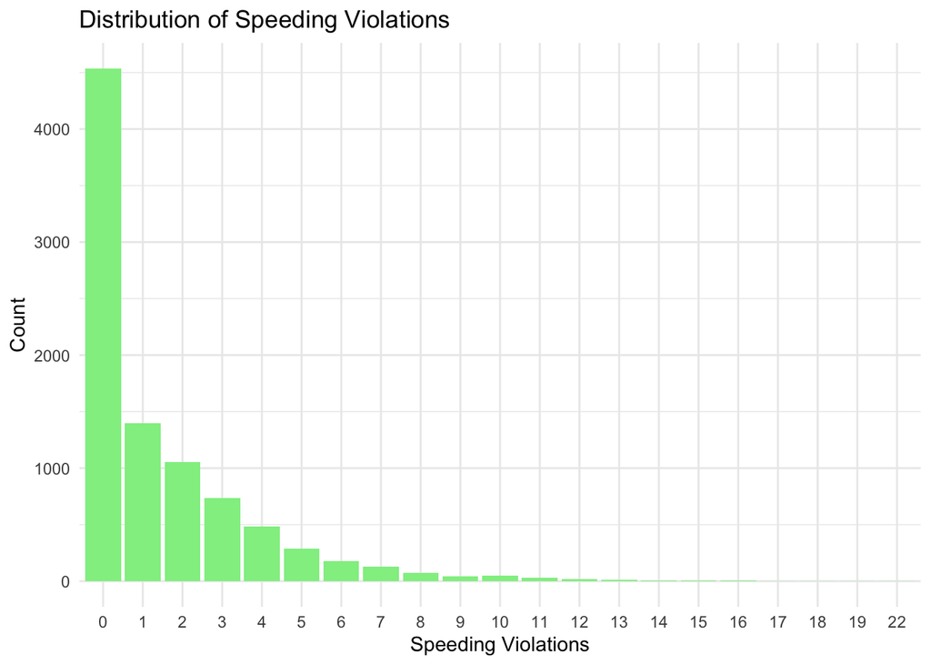

```r
# Bar chart for SPEEDING_VIOLATIONS
ggplot(data_clean, aes(x = factor(SPEEDING_VIOLATIONS))) +
  geom_bar(fill = color_light_green) +
  labs(title = "Distribution of Speeding Violations", x = "Speeding Violations", y = "Count") +
  theme_minimal()
```

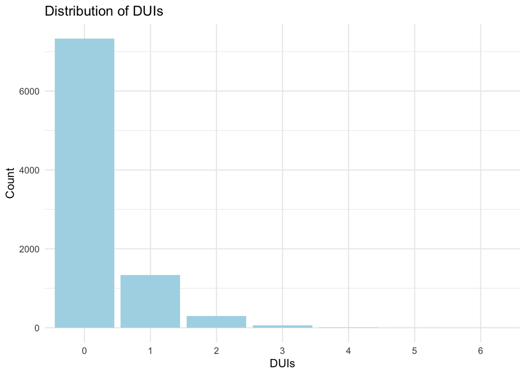

```r
# Bar chart for DUIS
ggplot(data_clean, aes(x = factor(DUIS))) +
  geom_bar(fill = color_light_blue) +
  labs(title = "Distribution of DUIs", x = "DUIs", y = "Count") +
  theme_minimal()
```

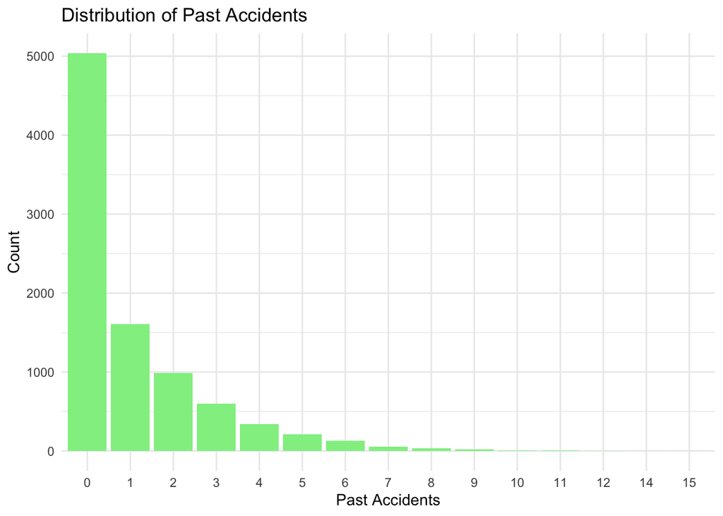

```r
# Bar chart for PAST_ACCIDENTS
ggplot(data_clean, aes(x = factor(PAST_ACCIDENTS))) +
  geom_bar(fill = color_light_green) +
  labs(title = "Distribution of Past Accidents", x = "Past Accidents", y = "Count") +
  theme_minimal()
```

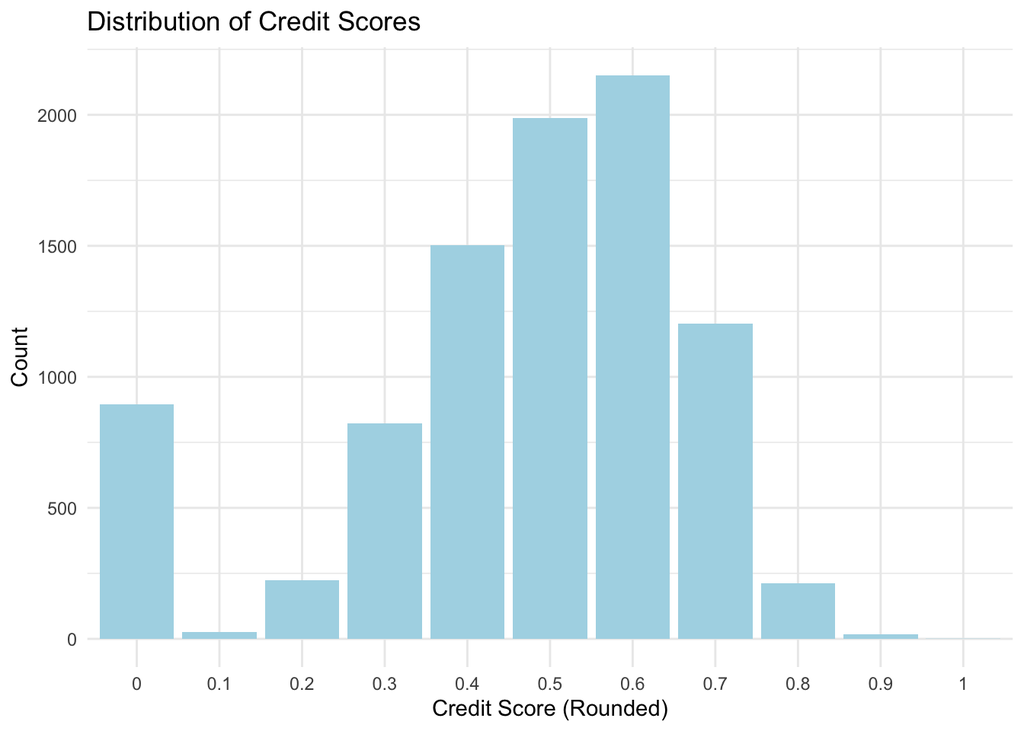

```r
# Bar chart for CREDIT_SCORE
ggplot(data_clean, aes(x = factor(round(CREDIT_SCORE, 1)))) +
  geom_bar(fill = color_light_blue) +
  labs(title = "Distribution of Credit Scores", x = "Credit Score (Rounded)", y = "Count") +
  theme_minimal()
```

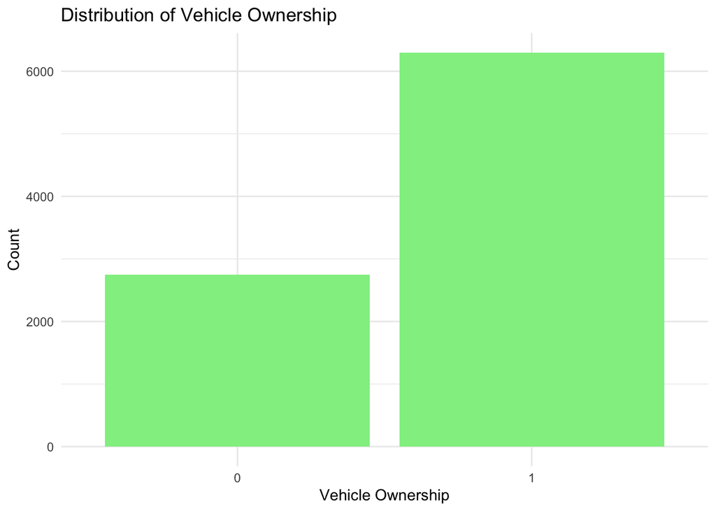

```r
# Bar chart for VEHICLE_OWNERSHIP
ggplot(data_clean, aes(x = factor(VEHICLE_OWNERSHIP))) +
  geom_bar(fill = color_light_green) +
  labs(title = "Distribution of Vehicle Ownership", x = "Vehicle Ownership", y = "Count") +
  theme_minimal()
```

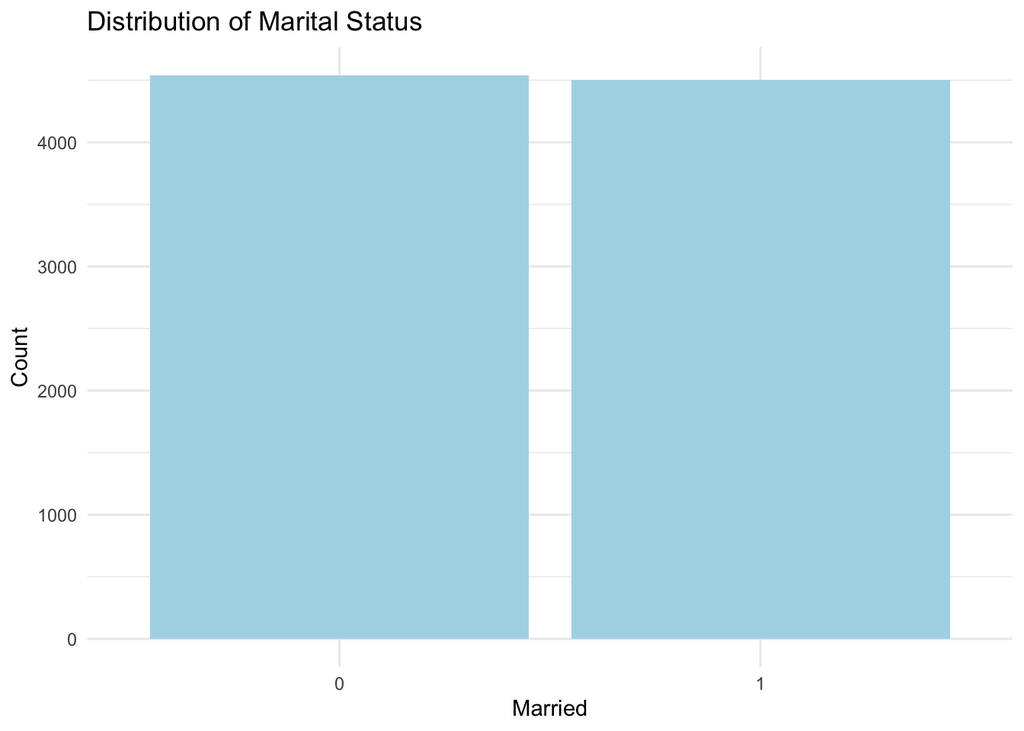

```r
# Bar chart for MARRIED
ggplot(data_clean, aes(x = factor(MARRIED))) +
  geom_bar(fill = color_light_blue) +
  labs(title = "Distribution of Marital Status", x = "Married", y = "Count") +
  theme_minimal()
```

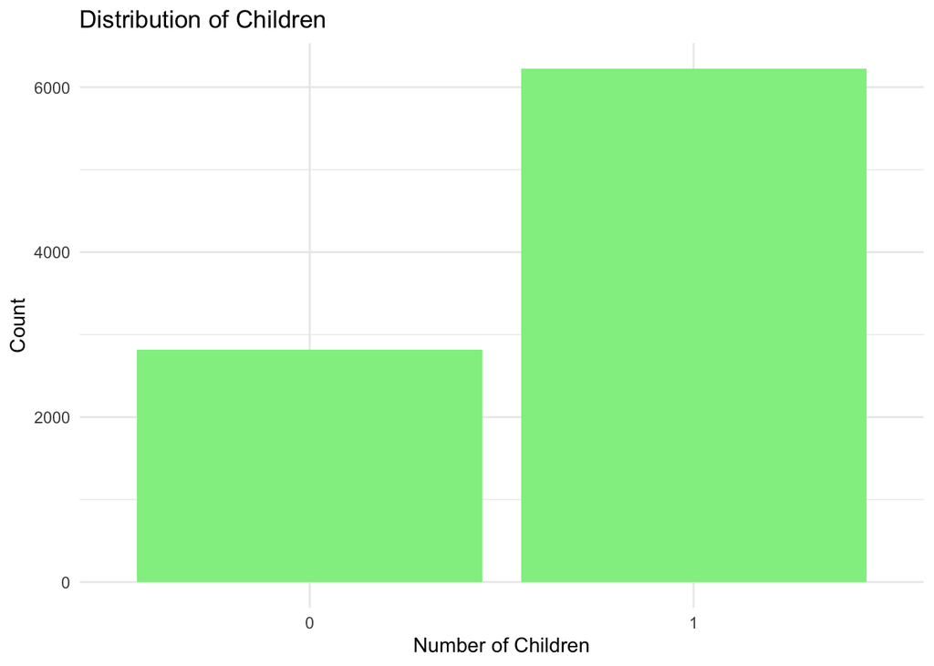

```r
# Bar chart for CHILDREN
ggplot(data_clean, aes(x = factor(CHILDREN))) +
  geom_bar(fill = color_light_green) +
  labs(title = "Distribution of Children", x = "Number of Children", y = "Count") +
  theme_minimal()
```

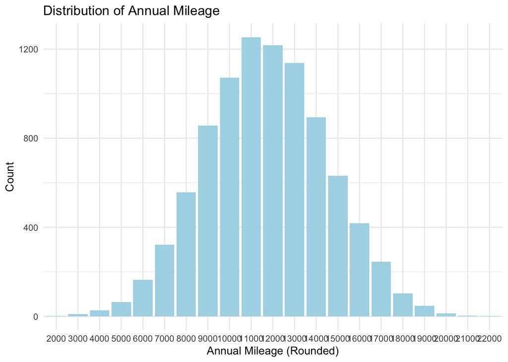

```r
# Bar chart for ANNUAL_MILEAGE
ggplot(data_clean, aes(x = factor(round(ANNUAL_MILEAGE, -3)))) +
  geom_bar(fill = color_light_blue) +
  labs(title = "Distribution of Annual Mileage", x = "Annual Mileage (Rounded)", y = "Count") +
  theme_minimal()
```